# Arbeidsfysiologisk metode og Statistikk

Kausal inferens: Quiz

## Spørsmål 1: Indentifisere en modell som beskriver en kausal effekt.

*Hvilken modell gir den kausale effekten av X på Y gitt figuren?*

- $Y = \beta_0 + \beta_1 X$
- $Y = \beta_0 + \beta_1 X + \beta_2 Z$
- $Y = \beta_0 + \beta_2 Z$
- $X = \beta_0 + \beta_1 Y$

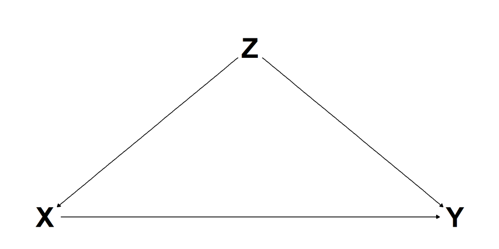

Figure 1: Hvordan estimere Y fra X?

## Spørsmål 2: Indentifisere en modell som beskriver en kausal effekt.

*Hvilken modell gir den kausale effekten av X på Y gitt figuren?*

- $Y = \beta_0 + \beta_1 X + \beta_2 Z + \beta_3 M$
- $Y = \beta_0 + \beta_1 X + \beta_2 M + \beta_3 G$
- $Y = \beta_0 + \beta_1 X + \beta_2 Z$
- $Y = \beta_0 + \beta_1 X$

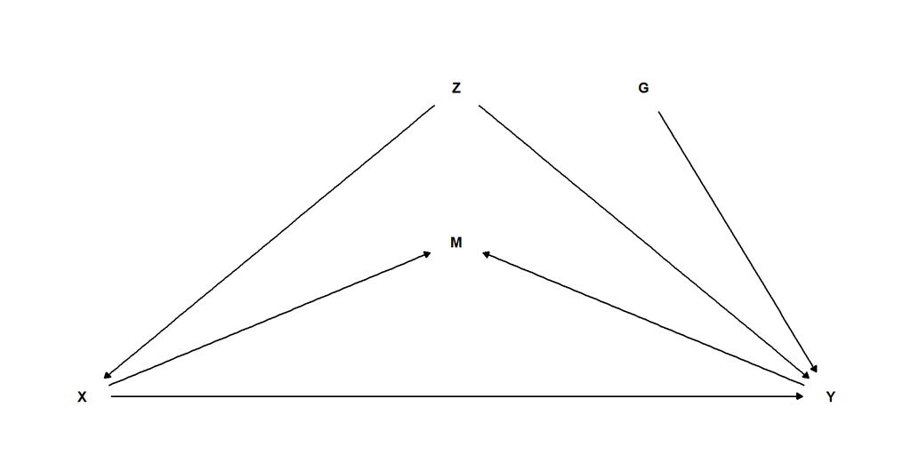

Figure 2: Hvordan estimere Y fra X?

## Spørsmål 3: Hva er effekten av X på Y gitt figuren og dataen?

*Hva er den kausale effekten av X på Y gitt figuren og dataen?* Angi svaret som gjennomsnittlig økning i Y for hver enhet økning i X, med to desimaler.

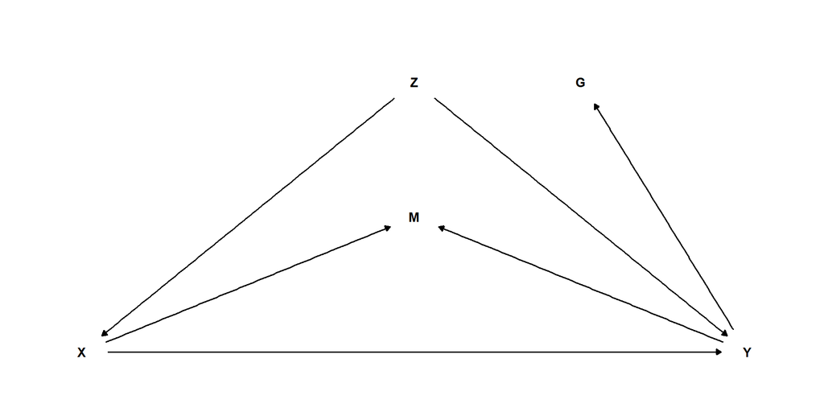

Figure 3: Hvordan estimere Y fra X?

## Spørsmål 3: Hva er effekten av X på Y gitt figuren og dataen?

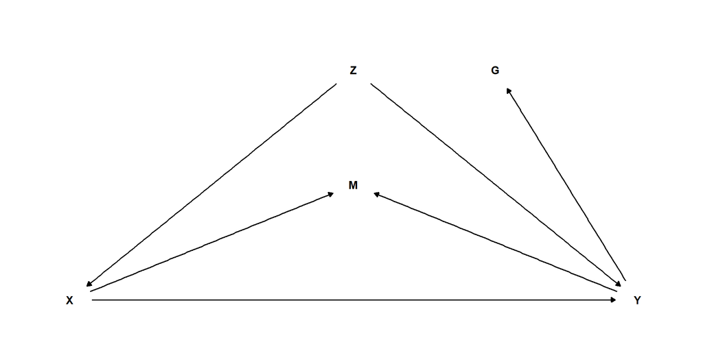

- `Y = X + Z:` 1.05
- `Y = X + Z + M:` -0.58
- `Y = X:` 1.37
- `Y = X + M:` -0.51

## Spørsmål 4: Hva er effekten av X på Y gitt figuren og dataen?

*Hva er den kausale effekten av X på Y gitt figuren og dataen?* Angi svaret som gjennomsnittlig differens mellom gruppene X i Y, med to desimaler.

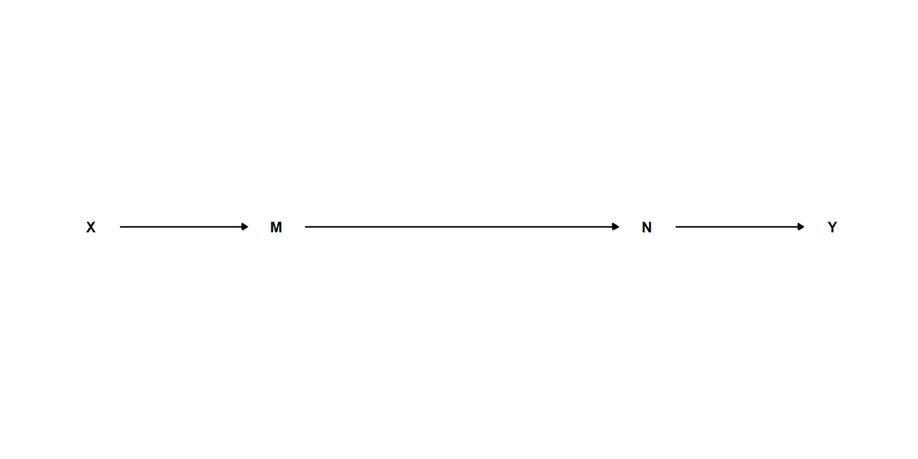

Figure 4: Hvordan estimere Y fra X?

## Spørsmål 4: Hva er effekten av X på Y gitt figuren og dataen?

- `Y = X:` -12.22
- `Y = X + M:` -4.41
- `Y = X + N:` -1.31

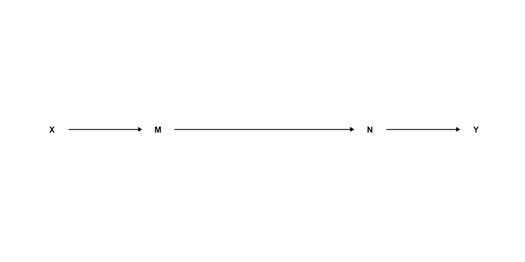

## Spørsmål 5: Estimer en sammenheng mellom X og Y

*Beregn sammenhengen mellom X og Y når `zcat == "high"`.* Angi svaret som gjennomsnittlig økning i Y for hver enhet økning i X, med to desimaler. Bruk et filter i Jamovi for å beregne svaret.

## Spørsmål 6: Estimer en sammenheng mellom X og Y

*Beregn sammenhengen mellom X og Y i hele datasettet.* Angi svaret som gjennomsnittlig økning i Y for hver enhet økning i X, med to desimaler.

## Spørsmål 7: Forklare en sammenheng.

*I datasettet med variablene x, y, z og zcat har du nå konstatert at det er en sammenheng mellom x og y når vi ser på dataene i en av kategoriene i zcat. Hvilken av følgende forklaringer er mest sannsynlig? Se også figuren under.*

- z (og dermed zcat) er en collider, når vi velger en kategori i zcat, åpner vi en ikke-kausal vei mellom x og y som ikke er tilstede i hele datasettet.
- z (og dermed zcat) er en konfunder, når vi velger en kategori i zcat, åpner vi en ikke-kausal vei mellom x og y som ikke er tilstede i hele datasettet.
- z (og dermed zcat) er en mediator, når vi velger en kategori i zcat analyserer vi effekten mellom x og y som ger gjennom z.

## Spørsmål 7: Forklare en sammenheng.

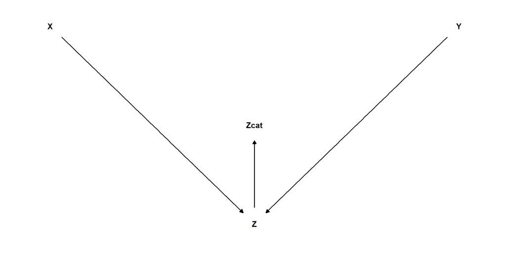

Figure 5: Hvordan estimere Y fra X?

## Spørsmål 8: Forklare en sammenheng.

Du leser en studie hvor det er funnet en sammenheng mellom fysisk aktivitet og hjertesykdom, forfatterne finner ferre tilfeller av hjertesykdom hos deltakere i studien som har en høyere nivå av fysisk aktivitet. Forskerne konkluderer med at fysisk aktivitet forhindrer hjertesykdom. Hvilken av følgende forklaringer er mest sannsynlig? Studien er en tverrsnittstudie i et brett utvalg av befolkningen.

- Fysisk aktivitet forhindrer hjertesykdom, ingen kontrollvariabler er nødvendige.
- Alder er en mulig konfunder som kan forsterke sammenhengen mellom fysisk aktivitet og hjertesykdom
- Fysisk aktivitet er en konfunder som kan forklare sammenhengen
- Fysisk aktivitet er en collider om kan forklare sammenhengen